# Exercise 6_1: A Map with many facets

Advanced Geospatial Data Processing for Social Scientists

Author

Dennis Abel & Stefan Jünger

### Exercises

Now that we know how to map several layers simultaneously with `ggplot()`, we want to explore the population in Texas in the four years 2017-2020. We will plot both `terra` and `stars` objects.

**🏋 Exercise 1**

In the previous session, we have created a raster stack and a raster cube for the four years in Texas. If these are not in your environment anymore, please load both (`./data/TX_pop_stack.tif` and `./data/TX_pop_cube.rds`).

In addition, load the county shapefiles for Texas with the `tigris` package. Reproject it to the CRS of your raster files.

**🏋 Exercise 2**

You are already proficient in creating publication-ready maps. Please create two plots - one for the `terra` object and another one for the `stars` object. Utilize the `facet_wrap()` command to separate the plot along the four years of the data.

Polish it as much as you like (NAs transparent, theme, titles, and North arrow and scale bar,…).

**🏋 Exercise 3**

Add your Texas counties shapefile to the plots with `geom_sf()`.

**🏋 Exercise 4**

Let’s use `ggplot` to create a plot which contains the shapefile and raster file. Adjust the color scheme by utilizing `scale_fill_viridis_c`, `scale_fill_distiller`, or `scale_fill_gradient2`.

**🏋 Exercise 5**

We want to point out counties which experience high population growth. Please attach labels to the top three counties by population growth. You can utilize `slice_head(n = 3)` after ordering the data in descending order to select only those three observations. Add this as an additional layer to the plot as text or text labels.

**🏋 Exercise 6**

What else could enhance your map? Polish it for publication, for example, by:

- Turn NAs transparent,
- Add titles,
- Adjust the overall theme of the plot,
- Add a North arrow and scale bar.

### Solutions

**✅ Solution 1**

```r
library(dplyr)
library(sf)
library(ggplot2)
library(terra)
library(tidyterra)
library(tigris)
library(stars)

# Load the raster data
TX_pop_stack <- terra::rast("./data/TX_pop_stack.tif")

# Load the raster cube
TX_pop_cube <- readRDS("./data/TX_pop_cube.rds")

# Load Texas county data
TX_counties <- tigris::counties("TX", progress_bar = FALSE)

crs_raster <- terra::crs(TX_pop_stack, describe = TRUE)$code

TX_counties <- TX_counties |>
  sf::st_transform(crs = as.numeric(crs_raster))
```

```
terra 1.8.29
```

[output not shown]

**✅ Solution 2**

```
<SpatRaster> resampled to 500850 cells.
```

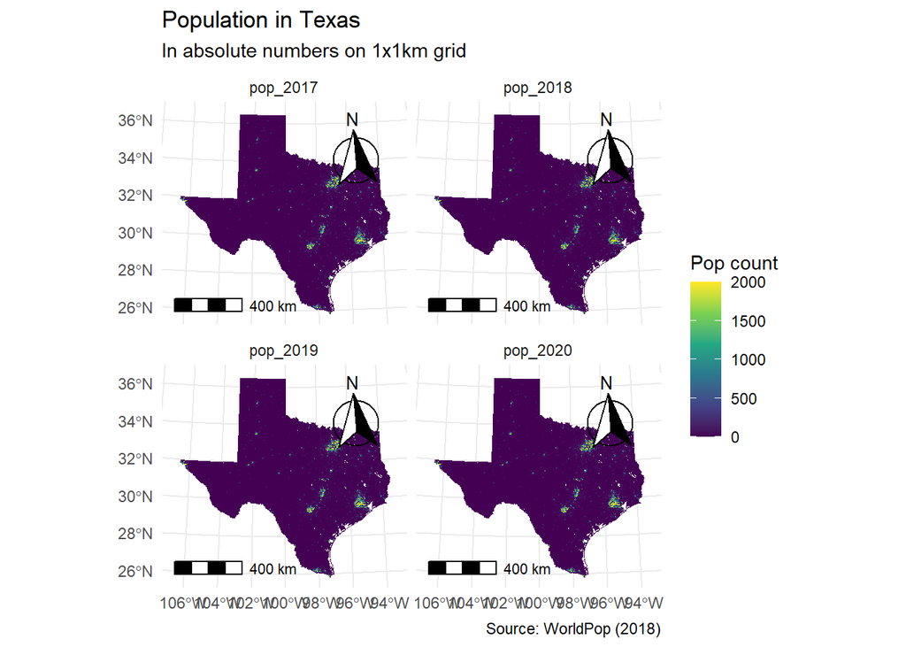

```r
library(ggspatial)

ggplot()+
  geom_spatraster(data = TX_pop_stack)+
  scale_fill_viridis_c(na.value = "transparent",
                       name = "Pop count",
                       limits = c(0, 2000),
                       oob = scales::squish)+
  facet_wrap(~ lyr)+
  theme_minimal()+
  labs(
    title = "Population in Texas",
    subtitle = "In absolute numbers on 1x1km grid",
    caption = "Source: WorldPop (2018)"
  ) +
  annotation_scale(
    location = "bl",
    width_hint = 0.3
  ) +
  annotation_north_arrow(
    location = "tr",
    which_north = "true",
    style = north_arrow_fancy_orienteering
  )
```

```
Using plotunit = 'm'
Using plotunit = 'm'
Using plotunit = 'm'
Using plotunit = 'm'
```

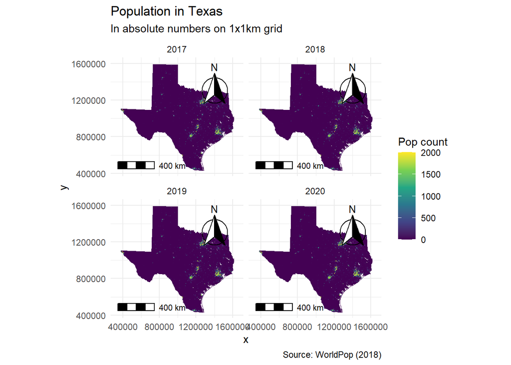

```r
library(ggspatial)

ggplot() +
  geom_stars(data = TX_pop_cube,
             aes(fill = population)
             ) +
  scale_fill_viridis_c(na.value = "transparent",
                       name = "Pop count",
                       limits = c(0, 2000),
                       oob = scales::squish)+
  coord_equal() +
  facet_wrap(~ time)+
  theme_minimal()+
  labs(
    title = "Population in Texas",
    subtitle = "In absolute numbers on 1x1km grid",
    caption = "Source: WorldPop (2018)"
  ) +
  annotation_scale(
    location = "bl",
    width_hint = 0.3
  ) +
  annotation_north_arrow(
    location = "tr",
    which_north = "true",
    style = north_arrow_fancy_orienteering
  )
```

**✅ Solution 3**

```
<SpatRaster> resampled to 500850 cells.
```

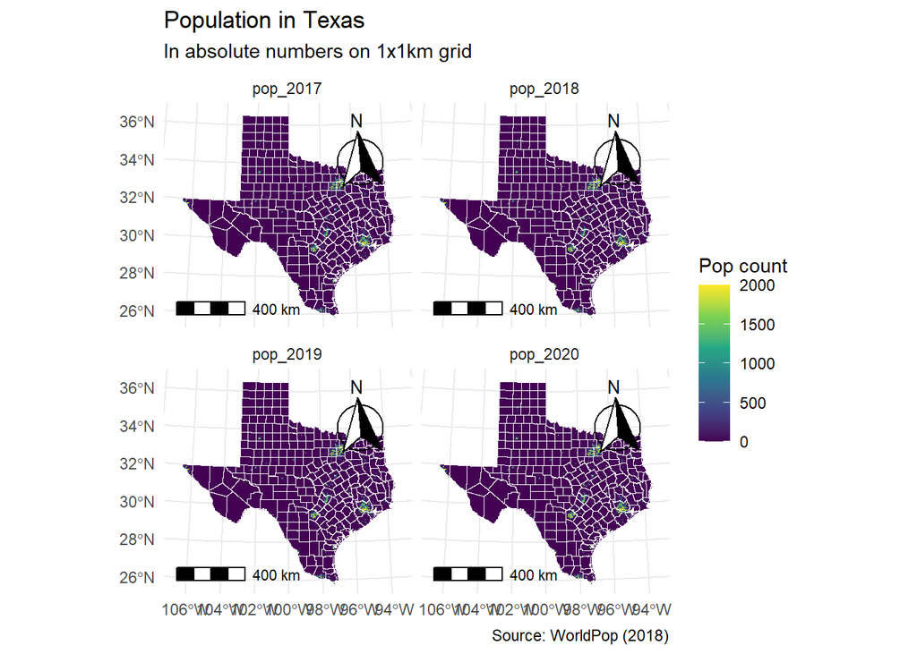

```r
library(ggspatial)

ggplot()+
  geom_spatraster(data = TX_pop_stack)+
  geom_sf(data = TX_counties,
          fill = "transparent",
          color = "white",
          size = 3)+
  scale_fill_viridis_c(na.value = "transparent",
                       name = "Pop count",
                       limits = c(0, 2000),
                       oob = scales::squish)+
  facet_wrap(~ lyr)+
  theme_minimal()+
  labs(
    title = "Population in Texas",
    subtitle = "In absolute numbers on 1x1km grid",
    caption = "Source: WorldPop (2018)"
  ) +
  annotation_scale(
    location = "bl",
    width_hint = 0.3
  ) +
  annotation_north_arrow(
    location = "tr",
    which_north = "true",
    style = north_arrow_fancy_orienteering
  )
```

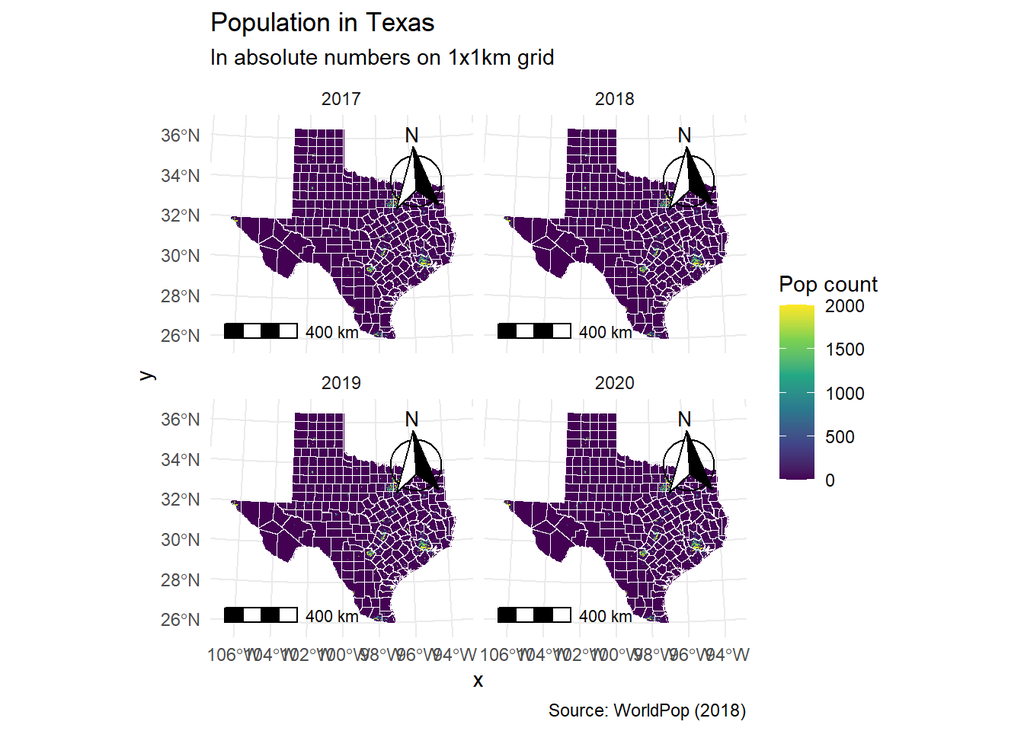

```r
library(ggspatial)

ggplot() +
  geom_stars(data = TX_pop_cube,
             aes(fill = population)
             ) +
  geom_sf(data = TX_counties,
          fill = "transparent",
          color = "white",
          size = 3)+
  scale_fill_viridis_c(na.value = "transparent",
                       name = "Pop count",
                       limits = c(0, 2000),
                       oob = scales::squish)+
  coord_sf() +
  facet_wrap(~ time)+
  theme_minimal()+
  labs(
    title = "Population in Texas",
    subtitle = "In absolute numbers on 1x1km grid",
    caption = "Source: WorldPop (2018)"
  ) +
  annotation_scale(
    location = "bl",
    width_hint = 0.3
  ) +
  annotation_north_arrow(
    location = "tr",
    which_north = "true",
    style = north_arrow_fancy_orienteering
  )
```